# tpaHH: Two-Piece Asymmetric Hybrid Hazard Regression Models

# 3 The TPA distribution family

These six functions define the two-piece asymmetric (TPA) distribution built from a symmetric reference distribution (`f0`, `F0`, `QF`) and a link function `g`. The construction follows Rubio & Steel-type two-piece distributions: a single location parameter `eta` splits the real line into two halves, each half is a stretched/compressed copy of the reference distribution, and `alpha` controls how much probability mass sits in each half (`alpha = 0.5` recovers the symmetric case).

```r
#' Density of the TPA family
#'
#' @param t vector of quantiles (time)
#' @param eta location parameter
#' @param phi scale parameter (phi > 0)
#' @param alpha skewness/index parameter in (0, 1)
#' @param f0 density of the reference distribution, e.g. f0_N
#' @param g link function applied to time, e.g. glog
#' @param log logical; if TRUE, the log-density is returned
#' @return numeric vector of (log-)density values, same length as t
#' @export
dtpa <- function(t, eta, phi, alpha, f0, g, log = FALSE) {
  # g.prime is the derivative of the link function, obtained symbolically
  # (this is why the Deriv package is required). For g = glog = log(t),
  # g.prime(t) = 1/t.
  g.prime <- Deriv::Deriv(g)

  # Common multiplicative term shared by both pieces of the density.
  com <- 2 * alpha * (1 - alpha) * g.prime(t) / phi

  # Left piece (t < eta) uses (1 - alpha) as the scale factor;
  # right piece (t >= eta) uses alpha. This is what makes the
  # distribution asymmetric around eta.
  den <- ifelse(t < eta,
                com * f0((1 - alpha) * (g(eta) - g(t)) / phi),
                com * f0(alpha * (g(t) - g(eta)) / phi))

  if (log) return(log(den)) else return(den)
}
```

```r
#' Cumulative distribution function (CDF) of the TPA family
#' @param q vector of quantiles (time)
#' @param eta,phi,alpha TPA parameters (see dtpa)
#' @param F0 CDF of the reference distribution, e.g. F0_N
#' @param g link function, e.g. glog
#' @param lower.tail logical; if FALSE, 1 - CDF (the survival function) is returned
#' @return numeric vector of (survival) probabilities
#' @export
ptpa <- function(q, eta, phi, alpha, F0, g, lower.tail = TRUE) {
  p <- ifelse(q < eta,
              2 * alpha * F0((1 - alpha) * (g(q) - g(eta)) / phi),
              2 * alpha - 1 + 2 * (1 - alpha) * F0(alpha * (g(q) - g(eta)) / phi))
  if (lower.tail) return(p) else return(1 - p)
}
```

```r
#' Hazard function of the TPA family: h(t) = f(t) / S(t)
#' @param t vector of quantiles (time)
#' @param eta,phi,alpha TPA parameters
#' @param f0 reference density
#' @param F0 reference CDF
#' @param g link function
#' @param log logical; if TRUE, the log-hazard is returned
#' @export
htpa <- function(t, eta, phi, alpha, f0, F0, g, log = FALSE) {
  dens <- dtpa(t, eta, phi, alpha, f0, g, log = FALSE)
  surv <- ptpa(t, eta, phi, alpha, F0, g, lower.tail = FALSE)
  h <- dens / surv
  if (log) return(log(h)) else return(h)
}
```

```r
#' Cumulative hazard function of the TPA family: H(t) = -log(S(t))
#' @param t vector of quantiles (time)
#' @param eta,phi,alpha TPA parameters
#' @param F0 reference CDF
#' @param g link function
#' @param log logical; if TRUE, log(H(t)) is returned
#' @export
Htpa <- function(t, eta, phi, alpha, F0, g, log = FALSE) {
  cmh <- -log(ptpa(t, eta, phi, alpha, F0, g, lower.tail = FALSE))
  if (log) return(log(cmh)) else return(cmh)
}
```

```r
#' Quantile function of the TPA family
#'
#' @param tau vector of probabilities in (0, 1)
#' @param eta,phi,alpha TPA parameters
#' @param F0 reference CDF
#' @param g link function
#' @param g.inv inverse link function; if NULL it is obtained numerically
#'   via GoFKernel::inverse()
#' @param QF analytic quantile function of the reference distribution
#'   (e.g. QF_N); if NULL it is obtained numerically via GoFKernel::inverse()
#' @return numeric vector of quantiles, same length as tau
#' @export
qtpa <- function(tau, eta, phi, alpha, F0, g, g.inv = NULL, QF = NULL) {
  # Fall back to numerical inversion when analytic forms are not supplied.
  if (is.null(QF)) {
    QF <- GoFKernel::inverse(F0, lower = -Inf, upper = Inf)
  }
  if (is.null(g.inv)) {
    g.inv <- GoFKernel::inverse(g, lower = 0, upper = Inf)
  }

  q <- vector()
  for (i in 1:length(tau)) {
    # Ca is the standardised quantile on the reference scale, computed
    # piecewise depending on which side of alpha the target probability
    # falls on.
    Ca <- ifelse(tau[i] < alpha,
                 (1 / (1 - alpha)) * QF(tau[i] / (2 * alpha)),
                 (1 / alpha) * QF((1 + tau[i] - 2 * alpha) / (2 * (1 - alpha))))
    q[i] <- g.inv(g(eta) + phi * Ca)
  }
  return(q)
}
```

```r
#' Random number generation from the TPA family (inverse-CDF method)
#' @param n number of draws
#' @param eta,phi,alpha TPA parameters
#' @param F0 reference CDF
#' @param g link function
#' @param QF quantile function of the reference distribution
#' @return numeric vector of n simulated survival times
#' @export
rtpa <- function(n, eta, phi, alpha, F0, g, QF) {
  u <- runif(n, min = 0, max = 1)
  r <- vector()
  for (i in 1:n) {
    r[i] <- qtpa(u[i], eta, phi, alpha, F0, g, QF)
  }
  return(r)
}
```

## 3.1 Quick visual check

The chunk below plots the TPA-normal density and hazard function for a skewed configuration (`alpha != 0.5`), as a sanity check that the functions above behave as expected.

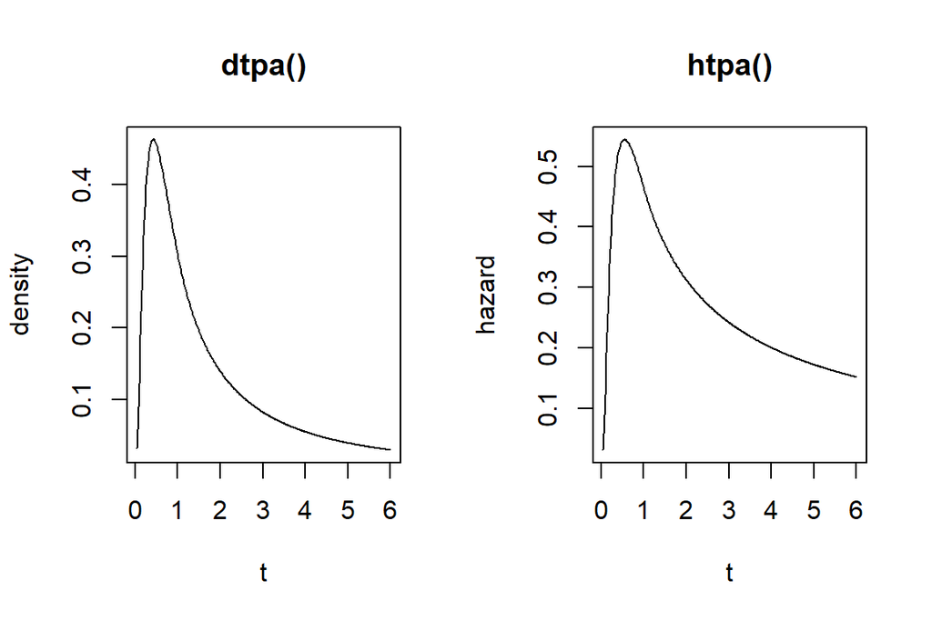

TPA-normal density and hazard for eta=1, phi=0.6, alpha=0.35

```r
tt <- seq(0.05, 6, length.out = 400)
par(mfrow = c(1, 2))
plot(tt, dtpa(tt, eta = 1, phi = 0.6, alpha = 0.35, f0 = f0_N, g = glog),
     type = "l", xlab = "t", ylab = "density", main = "dtpa()")
plot(tt, htpa(tt, eta = 1, phi = 0.6, alpha = 0.35, f0 = f0_N, F0 = F0_N, g = glog),
     type = "l", xlab = "t", ylab = "hazard", main = "htpa()")
```

```r
par(mfrow = c(1, 1))
```

# 4 Fully Parametric Regression Models

Each function in this section maximises a **negative log-likelihood** built from `htpa()`/`Htpa()` by a numerical optimiser (`optim()` or `nlminb()`), returning both the optimiser output and the negative log-likelihood function itself (useful later for standard errors, see `Conf.Int.FD()`).

All five functions share the same parameter-vector layout for the baseline distribution: `par[1] = log(eta)`, `par[2] = log(phi)`, `par[3] = logit(alpha)` (so `eta`, `phi` stay positive and `alpha` stays in (0, 1) during unconstrained optimisation), followed by regression coefficients.

| Function | Model | Covariate role(s) |
| --- | --- | --- |
| `parHH_mle()` | HH | `x1` on the time scale, `x2` on the hazard scale (both linear or `x2` profiled out if `psi2.hat` is supplied) |
| `parGH_mle()` | GH | same design matrix `x` used on both scales, with separate coefficient vectors |
| `parAFT_mle()` | AFT | `x` on the time scale only (pure acceleration) |
| `parPH_mle()` | PH | `x` on the hazard scale only (pure proportional hazards) |
| `parAH_mle()` | AH | `x` on the time scale, with the hazard-scale effect being the *negative* of the same linear predictor (accelerated hazards) |

```r
#' Maximum likelihood estimation for the parametric Hybrid Hazard (HH) model
#'
#' The HH model allows a covariate to act simultaneously on the time scale
#' (through x1) and the hazard scale (through x2). Semi-parametric use is
#' supported: pass a pre-estimated `psi2.hat` (a numeric vector, one value
#' per observation) to hold the hazard-scale linear predictor fixed while
#' profiling over the remaining parameters -- this is how the code is later
#' combined with the non-parametric estimators in Section 5.
#'
#' @param init numeric vector of starting values for the optimiser
#' @param y observed (possibly censored) survival times
#' @param delta event indicator (1 = event, 0 = censored)
#' @param x1 design matrix for the time-scale covariates (n x d1)
#' @param x2 design matrix for the hazard-scale covariates (n x d2)
#' @param dist baseline distribution: "tpalnorm", "tpallogis" or "tpalLap"
#' @param psi2.hat optional fixed hazard-scale linear predictor (length n);
#'   if supplied, the x2/beta2 block is not estimated
#' @param method optimiser: any `optim()` method, or "nlminb"
#' @param maxit maximum number of iterations (default 10000)
#' @return a list with `OPT` (raw optimiser output) and `nloglik`
#'   (the negative log-likelihood function used, for later reuse e.g. by
#'   `Conf.Int.FD()`)
#' @export
parHH_mle <- function(init, y, delta, x1, x2, dist, psi2.hat = NULL,
                       method = "Nelder-Mead", maxit = 10000, ...) {
  y <- as.vector(y)
  x1 <- as.matrix(x1)
  x2 <- as.matrix(x2)
  d1 <- dim(x1)[2]
  d2 <- dim(x2)[2]

  # --- TPA log-normal HH model --------------------------------------------
  if (dist == "tpalnorm") {
    nlog.lik <- function(par) {
      if (anyNA(par)) return(Inf)
      # Baseline parameters, transformed back to their natural scale.
      eta0 <- exp(par[1]); phi0 <- exp(par[2]); alpha0 <- expit(par[3])
      beta1 <- par[4:(3 + d1)]                 # time-scale regression coefficients
      psi.x1 <- as.vector(x1 %*% beta1)
      exp.psi.x1 <- exp(psi.x1)

      # If psi2.hat is not supplied, estimate beta2 along with everything
      # else; otherwise treat the hazard-scale linear predictor as known
      # (profiled out) -- this is the hook used for semi-parametric fits.
      if (is.null(psi2.hat)) {
        beta2 <- par[(4 + d1):(3 + d1 + d2)]
        psi.x2 <- as.vector(x2 %*% beta2)
      } else {
        psi.x2 <- psi2.hat
      }

      exp.psi.dif <- as.vector(exp(-psi.x1 + psi.x2))

      # Log-hazard contribution (evaluated at the time-rescaled argument
      # y * exp(psi.x1)) and cumulative-hazard contribution, combined into
      # the negative log-likelihood of a right-censored sample.
      lhaz0 <- htpa(y * exp.psi.x1, eta0, phi0, alpha0, f0_N, F0_N,
                    glog, log = TRUE) + psi.x2
      chaz0 <- Htpa(y * exp.psi.x1, eta0, phi0, alpha0, F0_N,
                    glog, log = FALSE) * exp.psi.dif
      lhaz0[is.infinite(lhaz0)] <- NA
      chaz0[is.infinite(chaz0)] <- NA
      val <- -sum(delta * lhaz0, na.rm = TRUE) + sum(chaz0, na.rm = TRUE)
      return(val)
    }
  }

  # --- TPA log-logistic HH model ------------------------------------------
  if (dist == "tpallogis") {
    nlog.lik <- function(par) {
      if (anyNA(par)) return(Inf)
      eta0 <- exp(par[1]); phi0 <- exp(par[2]); alpha0 <- expit(par[3])
      beta1 <- par[4:(3 + d1)]
      psi.x1 <- as.vector(x1 %*% beta1)
      exp.psi.x1 <- exp(psi.x1)

      if (is.null(psi2.hat)) {
        beta2 <- par[(4 + d1):(3 + d1 + d2)]
        psi.x2 <- as.vector(x2 %*% beta2)
      } else {
        psi.x2 <- psi2.hat
      }

      exp.psi.dif <- as.vector(exp(-psi.x1 + psi.x2))

      lhaz0 <- htpa(y * exp.psi.x1, eta0, phi0, alpha0, f0_Lo, F0_Lo,
                    glog, log = TRUE) + psi.x2
      chaz0 <- Htpa(y * exp.psi.x1, eta0, phi0, alpha0, F0_Lo,
                    glog, log = FALSE) * exp.psi.dif
      lhaz0[is.infinite(lhaz0)] <- NA
      chaz0[is.infinite(chaz0)] <- NA
      val <- -sum(delta * lhaz0, na.rm = TRUE) + sum(chaz0, na.rm = TRUE)
      return(val)
    }
  }

  # --- TPA log-Laplace HH model -------------------------------------------
  if (dist == "tpalLap") {
    nlog.lik <- function(par) {
      if (anyNA(par)) return(Inf)
      eta0 <- exp(par[1]); phi0 <- exp(par[2]); alpha0 <- expit(par[3])
      beta1 <- par[4:(3 + d1)]
      psi.x1 <- as.vector(x1 %*% beta1)
      exp.psi.x1 <- exp(psi.x1)

      if (is.null(psi2.hat)) {
        beta2 <- par[(4 + d1):(3 + d1 + d2)]
        psi.x2 <- as.vector(x2 %*% beta2)
      } else {
        psi.x2 <- psi2.hat
      }

      exp.psi.dif <- as.vector(exp(-psi.x1 + psi.x2))

      lhaz0 <- htpa(y * exp.psi.x1, eta0, phi0, alpha0, f0_La, F0_La,
                    glog, log = TRUE) + psi.x2
      chaz0 <- Htpa(y * exp.psi.x1, eta0, phi0, alpha0, F0_La,
                    glog, log = FALSE) * exp.psi.dif
      lhaz0[is.infinite(lhaz0)] <- NA
      chaz0[is.infinite(chaz0)] <- NA
      val <- -sum(delta * lhaz0, na.rm = TRUE) + sum(chaz0, na.rm = TRUE)
      return(val)
    }
  }

  # --- Optimisation ---------------------------------------------------------
  if (method != "nlminb") {
    OPT <- optim(init, nlog.lik, control = list(maxit = maxit), method = method)
  }
  if (method == "nlminb") {
    OPT <- nlminb(init, nlog.lik, control = list(iter.max = maxit))
  }
  OUT <- list(OPT = OPT, nloglik = nlog.lik)
  return(OUT)
}
```

```r
#' Maximum likelihood estimation for the parametric General Hazards (GH) model
#'
#' The GH model uses the *same* design matrix `x` for both the time scale
#' and the hazard scale, but with two separate coefficient vectors
#' (`beta1`, `beta2`). This differs from `parHH_mle()`, which allows two
#' different design matrices `x1`/`x2`.
#'
#' @inheritParams parHH_mle
#' @param x common design matrix for both scales (n x d)
#' @export
parGH_mle <- function(init, y, delta, x, dist, method = "Nelder-Mead",
                       maxit = 10000, ...) {
  y <- as.vector(y)
  delta <- as.vector(delta)
  x <- as.matrix(x)
  d <- dim(x)[2]

  if (dist == "tpalnorm") {
    nlog.lik <- function(par) {
      if (anyNA(par)) return(Inf)
      eta0 <- exp(par[1]); phi0 <- exp(par[2]); alpha0 <- expit(par[3])
      beta1 <- par[4:(3 + d)]          # time-scale coefficients
      beta2 <- par[(4 + d):(3 + 2 * d)] # hazard-scale coefficients

      psi.x1 <- as.vector(x %*% beta1)
      psi.x2 <- as.vector(x %*% beta2)

      exp.psi.x1 <- exp(psi.x1)
      exp.psi.dif <- as.vector(exp(-psi.x1 + psi.x2))

      lhaz0 <- htpa(y * exp.psi.x1, eta0, phi0, alpha0, f0_N, F0_N, glog, log = TRUE) + psi.x2
      chaz0 <- Htpa(y * exp.psi.x1, eta0, phi0, alpha0, F0_N, glog, log = FALSE) * exp.psi.dif
      lhaz0[is.infinite(lhaz0)] <- NA
      chaz0[is.infinite(chaz0)] <- NA
      val <- -sum(delta * lhaz0, na.rm = TRUE) + sum(chaz0, na.rm = TRUE)
      return(val)
    }
  }

  if (dist == "tpallogis") {
    nlog.lik <- function(par) {
      if (anyNA(par)) return(Inf)
      eta0 <- exp(par[1]); phi0 <- exp(par[2]); alpha0 <- expit(par[3])
      beta1 <- par[4:(3 + d)]
      beta2 <- par[(4 + d):(3 + 2 * d)]
      psi.x1 <- as.vector(x %*% beta1)
      psi.x2 <- as.vector(x %*% beta2)

      exp.psi.x1 <- exp(psi.x1)
      exp.psi.dif <- as.vector(exp(-psi.x1 + psi.x2))

      lhaz0 <- htpa(y * exp.psi.x1, eta0, phi0, alpha0, f0_Lo, F0_Lo, glog, log = TRUE) + psi.x2
      chaz0 <- Htpa(y * exp.psi.x1, eta0, phi0, alpha0, F0_Lo, glog, log = FALSE) * exp.psi.dif
      lhaz0[is.infinite(lhaz0)] <- NA
      chaz0[is.infinite(chaz0)] <- NA
      val <- -sum(delta * lhaz0, na.rm = TRUE) + sum(chaz0, na.rm = TRUE)
      return(val)
    }
  }

  if (dist == "tpalLap") {
    nlog.lik <- function(par) {
      if (anyNA(par)) return(Inf)
      eta0 <- exp(par[1]); phi0 <- exp(par[2]); alpha0 <- expit(par[3])
      beta1 <- par[4:(3 + d)]
      beta2 <- par[(4 + d):(3 + 2 * d)]

      psi.x1 <- as.vector(x %*% beta1)
      psi.x2 <- as.vector(x %*% beta2)

      exp.psi.x1 <- exp(psi.x1)
      exp.psi.dif <- as.vector(exp(-psi.x1 + psi.x2))

      lhaz0 <- htpa(y * exp.psi.x1, eta0, phi0, alpha0, f0_La, F0_La, glog, log = TRUE) + psi.x2
      chaz0 <- Htpa(y * exp.psi.x1, eta0, phi0, alpha0, F0_La, glog, log = FALSE) * exp.psi.dif
      lhaz0[is.infinite(lhaz0)] <- NA
      chaz0[is.infinite(chaz0)] <- NA
      val <- -sum(delta * lhaz0, na.rm = TRUE) + sum(chaz0, na.rm = TRUE)
      return(val)
    }
  }

  if (method != "nlminb") OPT <- optim(init, nlog.lik, control = list(maxit = maxit), method = method)
  if (method == "nlminb") OPT <- nlminb(init, nlog.lik, control = list(iter.max = maxit))
  OUT <- list(OPT = OPT, nloglik = nlog.lik)
  return(OUT)
}
```

```r
#' Maximum likelihood estimation for the parametric Accelerated Failure
#' Time (AFT) model (time-scale covariate effect only)
#'
#' @inheritParams parGH_mle
#' @param psihat optional fixed extra linear predictor (length n), added to
#'   the estimated x %*% beta term; defaults to a vector of zeros
#' @export
parAFT_mle <- function(init, y, delta, x, dist, method = "Nelder-Mead",
                        psihat = NULL, maxit = 10000, ...) {
  y <- as.vector(y)
  x <- as.matrix(x)
  d <- dim(x)[2]
  if (is.null(psihat)) {
    psi.x2 <- as.matrix(rep(0, length(y)))
  } else {
    psi.x2 <- psihat
  }

  if (dist == "tpalnorm") {
    nlog.lik <- function(par) {
      if (anyNA(par)) return(Inf)
      eta0 <- exp(par[1]); phi0 <- exp(par[2]); alpha0 <- expit(par[3])
      beta <- par[4:(3 + d)]
      psi.x1 <- as.vector(x %*% as.vector(beta))
      psi.x <- psi.x1 + psi.x2
      exp.psi.x <- exp(psi.x)

      # Note: in the pure AFT model the cumulative hazard is NOT rescaled
      # by exp.psi.x (unlike PH/HH) -- only the argument of the hazard is
      # rescaled by time (y * exp.psi.x). This is what makes it an
      # accelerated-*time* rather than a proportional-*hazard* model.
      lhaz0 <- htpa(y * exp.psi.x, eta0, phi0, alpha0, f0_N, F0_N, glog, log = TRUE) + psi.x
      chaz0 <- Htpa(y * exp.psi.x, eta0, phi0, alpha0, F0_N, glog, log = FALSE)
      lhaz0[is.infinite(lhaz0)] <- NA
      chaz0[is.infinite(chaz0)] <- NA
      val <- -sum(delta * lhaz0, na.rm = TRUE) + sum(chaz0, na.rm = TRUE)
      return(val)
    }
  }

  if (dist == "tpallogis") {
    nlog.lik <- function(par) {
      if (anyNA(par)) return(Inf)
      eta0 <- exp(par[1]); phi0 <- exp(par[2]); alpha0 <- expit(par[3])
      beta <- par[4:(3 + d)]
      psi.x1 <- as.vector(x %*% as.vector(beta))
      psi.x <- psi.x1 + psi.x2
      exp.psi.x <- exp(psi.x)

      lhaz0 <- htpa(y * exp.psi.x, eta0, phi0, alpha0, f0_Lo, F0_Lo, glog, log = TRUE) + psi.x
      chaz0 <- Htpa(y * exp.psi.x, eta0, phi0, alpha0, F0_Lo, glog, log = FALSE)
      lhaz0[is.infinite(lhaz0)] <- NA
      chaz0[is.infinite(chaz0)] <- NA
      val <- -sum(delta * lhaz0, na.rm = TRUE) + sum(chaz0, na.rm = TRUE)
      return(val)
    }
  }

  if (dist == "tpalLap") {
    nlog.lik <- function(par) {
      if (anyNA(par)) return(Inf)
      eta0 <- exp(par[1]); phi0 <- exp(par[2]); alpha0 <- expit(par[3])
      beta <- par[4:(3 + d)]
      psi.x1 <- as.vector(x %*% as.vector(beta))
      psi.x <- psi.x1 + psi.x2
      exp.psi.x <- exp(psi.x)

      lhaz0 <- htpa(y * exp.psi.x, eta0, phi0, alpha0, f0_La, F0_La, glog, log = TRUE) + psi.x
      chaz0 <- Htpa(y * exp.psi.x, eta0, phi0, alpha0, F0_La, glog, log = FALSE)
      lhaz0[is.infinite(lhaz0)] <- NA
      chaz0[is.infinite(chaz0)] <- NA
      val <- -sum(delta * lhaz0, na.rm = TRUE) + sum(chaz0, na.rm = TRUE)
      return(val)
    }
  }

  if (method != "nlminb") OPT <- optim(init, nlog.lik, control = list(maxit = maxit), method = method)
  if (method == "nlminb") OPT <- nlminb(init, nlog.lik, control = list(iter.max = maxit))
  OUT <- list(OPT = OPT, nloglik = nlog.lik)
  return(OUT)
}
```

```r
#' Maximum likelihood estimation for the parametric Proportional Hazards
#' (PH) model (hazard-scale covariate effect only)
#'
#' Also usable in a semi-parametric setting: pass a pre-estimated
#' `psihat` to hold the linear predictor fixed.
#'
#' @inheritParams parAFT_mle
#' @export
parPH_mle <- function(init, y, delta, x, dist, psihat = NULL,
                       method = "Nelder-Mead", maxit = 10000, ...) {
  y <- as.vector(y)
  x <- as.matrix(x)
  d <- dim(x)[2]
  if (is.null(psihat)) {
    psi.x2 <- as.matrix(rep(0, length(y)))
  } else {
    psi.x2 <- psihat
  }

  if (dist == "tpalnorm") {
    nlog.lik <- function(par) {
      if (anyNA(par)) return(Inf)
      eta0 <- exp(par[1]); phi0 <- exp(par[2]); alpha0 <- expit(par[3])
      beta <- par[4:(3 + d)]
      psi.x1 <- as.vector(x %*% as.vector(beta))
      psi.x <- psi.x1 + psi.x2
      exp.psi.x <- exp(psi.x)

      # PH model: time itself is NOT rescaled (unlike AFT); only the
      # hazard is multiplied by exp(psi.x) -- the defining property of a
      # proportional-hazards model.
      lhaz0 <- htpa(y, eta0, phi0, alpha0, f0_N, F0_N, glog, log = TRUE) + psi.x
      chaz0 <- Htpa(y, eta0, phi0, alpha0, F0_N, glog, log = FALSE) * exp.psi.x
      lhaz0[is.infinite(lhaz0)] <- NA
      chaz0[is.infinite(chaz0)] <- NA
      val <- -sum(delta * lhaz0, na.rm = TRUE) + sum(chaz0, na.rm = TRUE)
      return(val)
    }
  }

  if (dist == "tpallogis") {
    nlog.lik <- function(par) {
      if (anyNA(par)) return(Inf)
      eta0 <- exp(par[1]); phi0 <- exp(par[2]); alpha0 <- expit(par[3])
      # NOTE (kept as in the original script): unlike the tpalnorm branch
      # above, this branch and the tpalLap branch below check `psihat`
      # again here and re-derive psi.x from it, rather than reusing the
      # psi.x2 computed at the top of the function. Functionally
      # equivalent, but worth knowing if you are diffing against your own
      # modifications.
      if (is.null(psihat)) {
        beta <- par[4:(3 + d)]
        psi.x <- as.vector(x %*% beta)
        exp.psi.x <- exp(psi.x)
      } else {
        psi.x <- psihat
        exp.psi.x <- exp(psihat)
      }

      lhaz0 <- htpa(y, eta0, phi0, alpha0, f0_Lo, F0_Lo, glog, log = TRUE) + psi.x
      chaz0 <- Htpa(y, eta0, phi0, alpha0, F0_Lo, glog, log = FALSE) * exp.psi.x
      lhaz0[is.infinite(lhaz0)] <- NA
      chaz0[is.infinite(chaz0)] <- NA
      val <- -sum(delta * lhaz0, na.rm = TRUE) + sum(chaz0, na.rm = TRUE)
      return(val)
    }
  }

  if (dist == "tpalLap") {
    nlog.lik <- function(par) {
      if (anyNA(par)) return(Inf)
      eta0 <- exp(par[1]); phi0 <- exp(par[2]); alpha0 <- expit(par[3])
      if (is.null(psihat)) {
        beta <- par[4:(3 + d)]
        psi.x <- as.vector(x %*% beta)
        exp.psi.x <- exp(psi.x)
      } else {
        psi.x <- psihat
        exp.psi.x <- exp(psihat)
      }

      lhaz0 <- htpa(y, eta0, phi0, alpha0, f0_La, F0_La, glog, log = TRUE) + psi.x
      chaz0 <- Htpa(y, eta0, phi0, alpha0, F0_La, glog, log = FALSE) * exp.psi.x
      lhaz0[is.infinite(lhaz0)] <- NA
      chaz0[is.infinite(chaz0)] <- NA
      val <- -sum(delta * lhaz0, na.rm = TRUE) + sum(chaz0, na.rm = TRUE)
      return(val)
    }
  }

  if (method != "nlminb") OPT <- optim(init, nlog.lik, control = list(maxit = maxit), method = method)
  if (method == "nlminb") OPT <- nlminb(init, nlog.lik, control = list(iter.max = maxit))
  OUT <- list(OPT = OPT, nloglik = nlog.lik)
  return(OUT)
}
```

```r
#' Maximum likelihood estimation for the parametric Accelerated Hazards
#' (AH) model
#'
#' The AH model rescales time by exp(psi.x) (like AFT) AND divides the
#' cumulative hazard contribution by exp(psi.x) (i.e. multiplies by
#' exp(-psi.x)). This combination is what characterises the accelerated
#' hazards model, distinct from AFT and PH.
#'
#' @inheritParams parPH_mle
#' @export
parAH_mle <- function(init, y, delta, x, dist, psihat = NULL,
                       method = "Nelder-Mead", maxit = 10000, ...) {
  y <- as.vector(y)
  x <- as.matrix(x)
  d <- dim(x)[2]
  if (is.null(psihat)) {
    psi.x2 <- as.matrix(rep(0, length(y)))
  } else {
    psi.x2 <- psihat
  }

  if (dist == "tpalnorm") {
    nlog.lik <- function(par) {
      if (anyNA(par)) return(Inf)
      eta0 <- exp(par[1]); phi0 <- exp(par[2]); alpha0 <- expit(par[3])
      beta <- par[4:(3 + d)]
      psi.x1 <- as.vector(x %*% beta)
      psi.x <- psi.x1 + psi.x2
      exp.psi.x <- exp(psi.x)

      lhaz0 <- htpa(y * exp.psi.x, eta0, phi0, alpha0, f0_N, F0_N, glog, log = TRUE)
      chaz0 <- Htpa(y * exp.psi.x, eta0, phi0, alpha0, F0_N, glog, log = FALSE) * exp(-psi.x)
      lhaz0[is.infinite(lhaz0)] <- NA
      chaz0[is.infinite(chaz0)] <- NA
      val <- -sum(delta * lhaz0, na.rm = TRUE) + sum(chaz0, na.rm = TRUE)
      return(val)
    }
  }

  if (dist == "tpallogis") {
    nlog.lik <- function(par) {
      if (anyNA(par)) return(Inf)
      eta0 <- exp(par[1]); phi0 <- exp(par[2]); alpha0 <- expit(par[3])
      beta <- par[4:(3 + d)]
      psi.x1 <- as.vector(x %*% beta)
      psi.x <- psi.x1 + psi.x2
      exp.psi.x <- exp(psi.x)

      lhaz0 <- htpa(y * exp.psi.x, eta0, phi0, alpha0, f0_Lo, F0_Lo, glog, log = TRUE)
      chaz0 <- Htpa(y * exp.psi.x, eta0, phi0, alpha0, F0_Lo, glog, log = FALSE) * exp(-psi.x)
      lhaz0[is.infinite(lhaz0)] <- NA
      chaz0[is.infinite(chaz0)] <- NA
      val <- -sum(delta * lhaz0, na.rm = TRUE) + sum(chaz0, na.rm = TRUE)
      return(val)
    }
  }

  if (dist == "tpalLap") {
    nlog.lik <- function(par) {
      if (anyNA(par)) return(Inf)
      eta0 <- exp(par[1]); phi0 <- exp(par[2]); alpha0 <- expit(par[3])
      beta <- par[4:(3 + d)]
      psi.x1 <- as.vector(x %*% beta)
      psi.x <- psi.x1 + psi.x2
      exp.psi.x <- exp(psi.x)

      lhaz0 <- htpa(y * exp.psi.x, eta0, phi0, alpha0, f0_La, F0_La, glog, log = TRUE)
      chaz0 <- Htpa(y * exp.psi.x, eta0, phi0, alpha0, F0_La, glog, log = FALSE) * exp(-psi.x)
      lhaz0[is.infinite(lhaz0)] <- NA
      chaz0[is.infinite(chaz0)] <- NA
      val <- -sum(delta * lhaz0, na.rm = TRUE) + sum(chaz0, na.rm = TRUE)
      return(val)
    }
  }

  if (method != "nlminb") OPT <- optim(init, nlog.lik, control = list(maxit = maxit), method = method)
  if (method == "nlminb") OPT <- nlminb(init, nlog.lik, control = list(iter.max = maxit))
  OUT <- list(OPT = OPT, nloglik = nlog.lik)
  return(OUT)
}
```

# 5 Kernel function and semi-/non-parametric estimation

The functions in this section implement **local-likelihood** estimation of a smooth covariate effect, i.e. the non-parametric building block used when part of a model’s linear predictor is left unspecified. Estimation proceeds by:

1. picking a **kernel** (weight function) `ker()`,
2. centring the covariate of interest on a grid point `x0` and weighting nearby observations more heavily using bandwidth `h`, and
3. locally approximating the unknown smooth function by a second-order polynomial (a *local quadratic* fit), whose coefficients are estimated by maximising the kernel-weighted log-likelihood.

Each `nonpar*_mle()` function below is the local-likelihood, kernel-weighted counterpart of the corresponding `par*_mle()` function in Section 4, and each optionally “profiles out” a parametric part of the covariate effect (pass its index via `x21.index`/`x11.index` and its fitted coefficients via `beta2.hat`/`beta1.hat`) – this is what allows a genuinely **semi-parametric** model (part linear, part smooth) to be fitted.

```r
#' Kernel weight functions used for local-likelihood smoothing
#' @param ktype one of "uniform", "Gaussian", "Epan" (Epanechnikov,
#'   the default used throughout), "biweight", "triweight", "cosine"
#' @param x standardised distance (x0 - xi) / h
#' @return kernel weights, same length as x
#' @export
ker <- function(ktype, x) {
  if (ktype == "uniform") {
    result <- dunif(x, -1, 1)
  }
  if (ktype == "Gaussian") {
    result <- dnorm(x)
  } else if (ktype == "Epan") {
    result <- ifelse(abs(x) <= 1, 3 / 4 * (1 - x^2), 0)
  } else if (ktype == "biweight") {
    result <- ifelse(abs(x) <= 1, 15 / 16 * (1 - x^2)^2, 0)
  } else if (ktype == "triweight") {
    result <- ifelse(abs(x) <= 1, 35 / 32 * (1 - x^2)^3, 0)
  } else if (ktype == "cosine") {
    result <- ifelse(abs(x) <= 1, pi / 4 * cos(pi / 2 * x), 0)
  }
  return(result)
}
```

```r
#' Local-likelihood (semi-/non-parametric) estimation of the hazard-scale
#' smooth term in the HH model
#'
#' @param init optional starting values; if NULL, a degree-2 polynomial OLS
#'   fit on the (uncensored) data is used to construct starting values
#' @param y,delta observed times and event indicator
#' @param x1 time-scale design matrix (parametric part, already estimated
#'   via beta1.hat)
#' @param x2 hazard-scale covariate matrix; may combine a parametric block
#'   (columns given by `x21.index`, coefficients `beta2.hat`) and a
#'   non-parametric block (the remaining columns)
#' @param x21.index column indices of x2 that are modelled parametrically;
#'   NULL if the entire hazard-scale effect is non-parametric
#' @param theta.hat fitted (transformed) baseline parameters, i.e.
#'   `c(log(eta), log(phi), logit(alpha))`
#' @param beta1.hat fitted time-scale regression coefficients
#' @param beta2.hat fitted coefficients for the parametric block of x2
#'   (required if x21.index is supplied)
#' @param dist baseline distribution: "tpalnorm" or "tpallogis" (the
#'   log-Laplace case is not implemented for this estimator in the
#'   original code)
#' @param x0 the local grid point at which the smooth function is estimated
#' @param h bandwidth (> 0)
#' @param ktype kernel type, see `ker()`; defaults to "Epan"
#' @param method optimiser, "Nelder-Mead" (default) or "nlminb"
#' @param maxit maximum iterations
#' @return the fitted local polynomial coefficients at x0 (intercept,
#'   linear, quadratic term); the function value at x0 is the first element
#' @export
nonparHH_mle <- function(init = NULL, y, delta, x1, x2, x21.index = NULL,
                          theta.hat, beta1.hat, beta2.hat = NULL, dist,
                          x0, h, ktype = "Epan", method = "Nelder-Mead", maxit = 10000, ...) {
  if (is.na(h) || h <= 0L) stop("invalid 'bandwidth value.' ")
  if (is.null(colnames(x2))) stop("give a column names for the 'covariates'")

  y <- as.vector(y)
  delta <- as.vector(delta)
  x1 <- as.matrix(x1)
  d1 <- dim(x1)[2]
  n <- length(y)

  # Split x2 into a parametric block (x21) and the non-parametric block
  # (x22) that is actually being smoothed at this call.
  if (!is.null(x21.index) | !is.null(beta2.hat)) {
    x21 <- as.matrix(x2[, x21.index])
    d21 <- ncol(x21)
    x22 <- as.matrix(x2[, -c(1:d21)])
    d22 <- ncol(x22)
    psi.x21 <- as.vector(x21 %*% beta2.hat)
  } else {
    psi.x21 <- rep(0, n)
    x22 <- as.matrix(x2)
    d22 <- dim(x22)[2]
  }

  # Centre the non-parametric covariate(s) on the local point x0 and build
  # kernel weights, then a local design matrix up to the quadratic term.
  newx0 <- x22 - t(matrix(rep(x0, d22 * n), d22, n))
  ker.h <- as.vector(apply(newx0 / h, MARGIN = 2, FUN = ker, ktype = ktype) / h)
  newx <- cbind(1, newx0, newx0^2) # local quadratic (up to second derivative)

  if (is.null(init)) {
    fit.poly <- lm(y[delta == 1] ~ poly(newx0[delta == 1], degree = 2))
    init <- as.numeric(fit.poly$coefficients)
  }

  if (dist == "tpalnorm") {
    nlog.lik <- function(par) {
      if (anyNA(par)) return(Inf)
      eta0 <- exp(theta.hat[1]); phi0 <- exp(theta.hat[2]); alpha0 <- expit(theta.hat[3])
      b2 <- par
      psi.x22 <- as.vector(newx %*% b2)

      psi.x2 <- psi.x21 + psi.x22
      psi.x1 <- as.vector(x1 %*% beta1.hat)
      exp.psi.x1 <- exp(psi.x1)
      exp.psi.dif <- exp(-psi.x1 + psi.x2)

      lhaz0 <- htpa(y * exp.psi.x1, eta0, phi0, alpha0, f0_N, F0_N, glog, log = TRUE) + psi.x2
      chaz0 <- Htpa(y * exp.psi.x1, eta0, phi0, alpha0, F0_N, glog, log = FALSE) * exp.psi.dif
      lhaz0[is.infinite(lhaz0)] <- NA
      chaz0[is.infinite(chaz0)] <- NA
      # Kernel-weighted (local) negative log-likelihood.
      val <- -sum(delta * lhaz0 * ker.h, na.rm = TRUE) + sum(chaz0 * ker.h, na.rm = TRUE)
      return(val)
    }
  }

  if (dist == "tpallogis") {
    nlog.lik <- function(par) {
      if (anyNA(par)) return(Inf)
      eta0 <- exp(theta.hat[1]); phi0 <- exp(theta.hat[2]); alpha0 <- expit(theta.hat[3])
      b2 <- par
      psi.x22 <- as.vector(newx %*% b2)

      psi.x2 <- psi.x21 + psi.x22
      psi.x1 <- as.vector(x1 %*% beta1.hat)
      exp.psi.x1 <- exp(psi.x1)
      exp.psi.dif <- exp(-psi.x1 + psi.x2)

      lhaz0 <- htpa(y * exp.psi.x1, eta0, phi0, alpha0, f0_Lo, F0_Lo, glog, log = TRUE) + psi.x2
      chaz0 <- Htpa(y * exp.psi.x1, eta0, phi0, alpha0, F0_Lo, glog, log = FALSE) * exp.psi.dif
      lhaz0[is.infinite(lhaz0)] <- NA
      chaz0[is.infinite(chaz0)] <- NA
      val <- -sum(delta * lhaz0 * ker.h, na.rm = TRUE) + sum(chaz0 * ker.h, na.rm = TRUE)
      return(val)
    }
  }

  if (method != "nlminb") OPT <- optim(init, nlog.lik, control = list(maxit = maxit), method = method)
  if (method == "nlminb") OPT <- nlminb(init, nlog.lik, control = list(iter.max = maxit))
  OUT <- OPT$par
  return(OUT)
}
```

```r
#' Local-likelihood estimation of the hazard-scale smooth term in the PH
#' model (no time-scale rescaling)
#' @inheritParams nonparHH_mle
#' @param x2 as in nonparHH_mle
#' @export
nonparPH_mle <- function(init = NULL, y, delta, x2, x21.index = NULL,
                          theta.hat, beta2.hat = NULL, dist,
                          x0, h, ktype = "Epan", method = "Nelder-Mead", maxit = 10000, ...) {
  if (is.na(h) || h <= 0L) stop("invalid 'bandwidth value.' ")
  if (is.null(colnames(x2))) stop("give a column names for the 'covariates'")

  y <- as.vector(y)
  delta <- as.vector(delta)
  n <- length(y)

  if (!is.null(x21.index) | !is.null(beta2.hat)) {
    x21 <- as.matrix(x2[, x21.index])
    d21 <- ncol(x21)
    x22 <- as.matrix(x2[, -c(1:d21)])
    d22 <- ncol(x22)
    psi.x21 <- as.vector(x21 %*% beta2.hat)
  } else {
    psi.x21 <- rep(0, n)
    x22 <- as.matrix(x2)
    d22 <- dim(x22)[2]
  }

  newx0 <- x22 - t(matrix(rep(x0, d22 * n), d22, n))
  ker.h <- as.vector(apply(newx0 / h, MARGIN = 2, FUN = ker, ktype = ktype) / h)
  newx <- cbind(1, newx0, newx0^2)

  if (is.null(init)) {
    fit.poly <- lm(y[delta == 1] ~ poly(newx0[delta == 1], degree = 2))
    init <- as.numeric(fit.poly$coefficients)
  }

  if (dist == "tpalnorm") {
    nlog.lik <- function(par) {
      if (anyNA(par)) return(Inf)
      eta0 <- exp(theta.hat[1]); phi0 <- exp(theta.hat[2]); alpha0 <- expit(theta.hat[3])
      b2 <- par
      psi.x22 <- as.vector(newx %*% b2)
      psi.x2 <- psi.x21 + psi.x22

      # PH model: time is not rescaled; the hazard is scaled multiplicatively.
      lhaz0 <- htpa(y, eta0, phi0, alpha0, f0_N, F0_N, glog, log = TRUE) + psi.x2
      chaz0 <- Htpa(y, eta0, phi0, alpha0, F0_N, glog, log = FALSE) * exp(psi.x2)
      lhaz0[is.infinite(lhaz0)] <- NA
      chaz0[is.infinite(chaz0)] <- NA
      val <- -sum(delta * lhaz0 * ker.h, na.rm = TRUE) + sum(chaz0 * ker.h, na.rm = TRUE)
      return(val)
    }
  }

  if (dist == "tpallogis") {
    nlog.lik <- function(par) {
      if (anyNA(par)) return(Inf)
      eta0 <- exp(theta.hat[1]); phi0 <- exp(theta.hat[2]); alpha0 <- expit(theta.hat[3])
      b2 <- par
      psi.x22 <- as.vector(newx %*% b2)
      psi.x2 <- psi.x21 + psi.x22

      lhaz0 <- htpa(y, eta0, phi0, alpha0, f0_Lo, F0_Lo, glog, log = TRUE) + psi.x2
      chaz0 <- Htpa(y, eta0, phi0, alpha0, F0_Lo, glog, log = FALSE) * exp(psi.x2)
      lhaz0[is.infinite(lhaz0)] <- NA
      chaz0[is.infinite(chaz0)] <- NA
      val <- -sum(delta * lhaz0 * ker.h, na.rm = TRUE) + sum(chaz0 * ker.h, na.rm = TRUE)
      return(val)
    }
  }

  if (dist == "tpalLap") {
    nlog.lik <- function(par) {
      if (anyNA(par)) return(Inf)
      eta0 <- exp(theta.hat[1]); phi0 <- exp(theta.hat[2]); alpha0 <- expit(theta.hat[3])
      b2 <- par
      psi.x22 <- as.vector(newx %*% b2)
      psi.x2 <- psi.x21 + psi.x22

      lhaz0 <- htpa(y, eta0, phi0, alpha0, f0_La, F0_La, glog, log = TRUE) + psi.x2
      chaz0 <- Htpa(y, eta0, phi0, alpha0, F0_La, glog, log = FALSE) * exp(psi.x2)
      lhaz0[is.infinite(lhaz0)] <- NA
      chaz0[is.infinite(chaz0)] <- NA
      val <- -sum(delta * lhaz0 * ker.h, na.rm = TRUE) + sum(chaz0 * ker.h, na.rm = TRUE)
      return(val)
    }
  }

  if (method != "nlminb") OPT <- optim(init, nlog.lik, control = list(maxit = maxit), method = method)
  if (method == "nlminb") OPT <- nlminb(init, nlog.lik, control = list(iter.max = maxit))
  OUT <- OPT$par
  return(OUT)
}
```

```r
#' Local-likelihood estimation of the time-scale smooth term in the AFT
#' model
#' @inheritParams nonparHH_mle
#' @param x design matrix; may combine a parametric block (`x11.index`,
#'   `beta1.hat`) and a non-parametric block
#' @export
nonparAFT_mle <- function(init = NULL, y, delta, x, x11.index = NULL,
                           theta.hat, beta1.hat = NULL, dist,
                           x0, h, ktype = "Epan", method = "Nelder-Mead", maxit = 10000, ...) {
  if (is.na(h) || h <= 0L) stop("invalid 'bandwidth value.' ")
  if (is.null(colnames(x))) stop("give a column names for the 'covariates'")

  y <- as.vector(y)
  delta <- as.vector(delta)
  n <- length(y)

  if (!is.null(x11.index) | !is.null(beta1.hat)) {
    x11 <- as.matrix(x[, x11.index])
    d11 <- ncol(x11)
    x12 <- as.matrix(x[, -c(1:d11)])
    d12 <- ncol(x12)
    psi.x11 <- as.vector(x11 %*% beta1.hat)
  } else {
    psi.x11 <- rep(0, n)
    x12 <- as.matrix(x)
    d12 <- dim(x12)[2]
  }

  newx0 <- x12 - t(matrix(rep(x0, d12 * n), d12, n))
  ker.h <- as.vector(apply(newx0 / h, MARGIN = 2, FUN = ker, ktype = ktype) / h)
  newx <- cbind(1, newx0, newx0^2)

  if (is.null(init)) {
    fit.poly <- lm(y[delta == 1] ~ poly(newx0[delta == 1], degree = 2))
    init <- as.numeric(fit.poly$coefficients)
  }

  if (dist == "tpalnorm") {
    nlog.lik <- function(par) {
      if (anyNA(par)) return(Inf)
      eta0 <- exp(theta.hat[1]); phi0 <- exp(theta.hat[2]); alpha0 <- expit(theta.hat[3])
      b1 <- par
      psi.x12 <- as.vector(newx %*% b1)
      psi.x <- psi.x11 + psi.x12

      lhaz0 <- htpa(y * exp(psi.x), eta0, phi0, alpha0, f0_N, F0_N, glog, log = TRUE) + psi.x
      chaz0 <- Htpa(y * exp(psi.x), eta0, phi0, alpha0, F0_N, glog, log = FALSE)
      lhaz0[is.infinite(lhaz0)] <- NA
      chaz0[is.infinite(chaz0)] <- NA
      val <- -sum(delta * lhaz0 * ker.h, na.rm = TRUE) + sum(chaz0 * ker.h, na.rm = TRUE)
      return(val)
    }
  }

  if (dist == "tpallogis") {
    nlog.lik <- function(par) {
      if (anyNA(par)) return(Inf)
      eta0 <- exp(theta.hat[1]); phi0 <- exp(theta.hat[2]); alpha0 <- expit(theta.hat[3])
      b1 <- par
      psi.x12 <- as.vector(newx %*% b1)
      psi.x <- psi.x11 + psi.x12

      lhaz0 <- htpa(y * exp(psi.x), eta0, phi0, alpha0, f0_Lo, F0_Lo, glog, log = TRUE) + psi.x
      chaz0 <- Htpa(y * exp(psi.x), eta0, phi0, alpha0, F0_Lo, glog, log = FALSE)
      lhaz0[is.infinite(lhaz0)] <- NA
      chaz0[is.infinite(chaz0)] <- NA
      val <- -sum(delta * lhaz0 * ker.h, na.rm = TRUE) + sum(chaz0 * ker.h, na.rm = TRUE)
      return(val)
    }
  }

  if (dist == "tpalLap") {
    nlog.lik <- function(par) {
      if (anyNA(par)) return(Inf)
      eta0 <- exp(theta.hat[1]); phi0 <- exp(theta.hat[2]); alpha0 <- expit(theta.hat[3])
      b1 <- par
      psi.x12 <- as.vector(newx %*% b1)
      psi.x <- psi.x11 + psi.x12

      lhaz0 <- htpa(y * exp(psi.x), eta0, phi0, alpha0, f0_La, F0_La, glog, log = TRUE) + psi.x
      chaz0 <- Htpa(y * exp(psi.x), eta0, phi0, alpha0, F0_La, glog, log = FALSE)
      lhaz0[is.infinite(lhaz0)] <- NA
      chaz0[is.infinite(chaz0)] <- NA
      val <- -sum(delta * lhaz0 * ker.h, na.rm = TRUE) + sum(chaz0 * ker.h, na.rm = TRUE)
      return(val)
    }
  }

  if (method != "nlminb") OPT <- optim(init, nlog.lik, control = list(maxit = maxit), method = method)
  if (method == "nlminb") OPT <- nlminb(init, nlog.lik, control = list(iter.max = maxit))
  OUT <- OPT$par
  return(OUT)
}
```

```r
#' Local-likelihood estimation of the time-scale smooth term in the AH
#' model
#' @inheritParams nonparAFT_mle
#' @export
nonparAH_mle <- function(init = NULL, y, delta, x, x11.index = NULL,
                          theta.hat, beta1.hat = NULL, dist,
                          x0, h, ktype = "Epan", method = "Nelder-Mead", maxit = 10000, ...) {
  if (is.na(h) || h <= 0L) stop("invalid 'bandwidth value.' ")
  if (is.null(colnames(x))) stop("give a column names for the 'covariates'")

  y <- as.vector(y)
  delta <- as.vector(delta)
  n <- length(y)

  if (!is.null(x11.index) | !is.null(beta1.hat)) {
    x11 <- as.matrix(x[, x11.index])
    d11 <- ncol(x11)
    x12 <- as.matrix(x[, -c(1:d11)])
    d12 <- ncol(x12)
    psi.x11 <- as.vector(x11 %*% beta1.hat)
  } else {
    psi.x11 <- rep(0, n)
    x12 <- as.matrix(x)
    d12 <- dim(x12)[2]
  }

  newx0 <- x12 - t(matrix(rep(x0, d12 * n), d12, n))
  ker.h <- as.vector(apply(newx0 / h, MARGIN = 2, FUN = ker, ktype = ktype) / h)
  newx <- cbind(1, newx0, newx0^2)

  if (is.null(init)) {
    fit.poly <- lm(y[delta == 1] ~ poly(newx0[delta == 1], degree = 2))
    init <- as.numeric(fit.poly$coefficients)
  }

  if (dist == "tpalnorm") {
    nlog.lik <- function(par) {
      if (anyNA(par)) return(Inf)
      eta0 <- exp(theta.hat[1]); phi0 <- exp(theta.hat[2]); alpha0 <- expit(theta.hat[3])
      b1 <- par
      psi.x12 <- as.vector(newx %*% b1)
      psi.x <- psi.x11 + psi.x12

      # AH model: time rescaled by exp(psi.x), cumulative hazard divided
      # by exp(psi.x) (i.e. multiplied by exp(-psi.x)).
      lhaz0 <- htpa(y * exp(psi.x), eta0, phi0, alpha0, f0_N, F0_N, glog, log = TRUE)
      chaz0 <- Htpa(y * exp(psi.x), eta0, phi0, alpha0, F0_N, glog, log = FALSE) * exp(-psi.x)
      lhaz0[is.infinite(lhaz0)] <- NA
      chaz0[is.infinite(chaz0)] <- NA
      val <- -sum(delta * lhaz0 * ker.h, na.rm = TRUE) + sum(chaz0 * ker.h, na.rm = TRUE)
      return(val)
    }
  }

  if (dist == "tpallogis") {
    nlog.lik <- function(par) {
      if (anyNA(par)) return(Inf)
      eta0 <- exp(theta.hat[1]); phi0 <- exp(theta.hat[2]); alpha0 <- expit(theta.hat[3])
      b1 <- par
      psi.x12 <- as.vector(newx %*% b1)
      psi.x <- psi.x11 + psi.x12

      lhaz0 <- htpa(y * exp(psi.x), eta0, phi0, alpha0, f0_Lo, F0_Lo, glog, log = TRUE)
      chaz0 <- Htpa(y * exp(psi.x), eta0, phi0, alpha0, F0_Lo, glog, log = FALSE) * exp(-psi.x)
      lhaz0[is.infinite(lhaz0)] <- NA
      chaz0[is.infinite(chaz0)] <- NA
      val <- -sum(delta * lhaz0 * ker.h, na.rm = TRUE) + sum(chaz0 * ker.h, na.rm = TRUE)
      return(val)
    }
  }

  if (dist == "tpalLap") {
    nlog.lik <- function(par) {
      if (anyNA(par)) return(Inf)
      eta0 <- exp(theta.hat[1]); phi0 <- exp(theta.hat[2]); alpha0 <- expit(theta.hat[3])
      b1 <- par
      psi.x12 <- as.vector(newx %*% b1)
      psi.x <- psi.x11 + psi.x12

      lhaz0 <- htpa(y * exp(psi.x), eta0, phi0, alpha0, f0_La, F0_La, glog, log = TRUE)
      chaz0 <- Htpa(y * exp(psi.x), eta0, phi0, alpha0, F0_La, glog, log = FALSE) * exp(-psi.x)
      lhaz0[is.infinite(lhaz0)] <- NA
      chaz0[is.infinite(chaz0)] <- NA
      val <- -sum(delta * lhaz0 * ker.h, na.rm = TRUE) + sum(chaz0 * ker.h, na.rm = TRUE)
      return(val)
    }
  }

  if (method != "nlminb") OPT <- optim(init, nlog.lik, control = list(maxit = maxit), method = method)
  if (method == "nlminb") OPT <- nlminb(init, nlog.lik, control = list(iter.max = maxit))
  OUT <- OPT$par
  return(OUT)
}
```

# 6 Post-estimation tools

```r
#' Average squared error between two survival curves
#' @param true_sp true/reference survival probabilities
#' @param pred_sp predicted survival probabilities
#' @return a single numeric value (the mean squared difference)
#' @export
surv_ase <- function(true_sp, pred_sp) {
  if (length(true_sp) != length(pred_sp))
    stop(" Error: surv_sp and pred_sp must have equal length")
  d <- (true_sp - pred_sp)^2
  return(ase = mean(d, na.rm = TRUE))
}
```

```r
#' Predicted survival, hazard, cumulative hazard, or quantile from a fitted
#' TPA (or "EW") model
#'
#' @param tau probability(-ies) for `type = "quantile"` (in (0,1))
#' @param theta transformed baseline parameters `c(log(eta), log(phi),
#'   logit(alpha))` -- NOTE: the function body actually reads these from an
#'   object called `par`, not from the `theta` argument (see the "Known
#'   limitations" note in Section 9); supply a global/enclosing `par`
#'   vector with the natural-scale baseline parameters `c(eta, phi, alpha)`
#'   until this is corrected
#' @param time vector of times at which to predict
#' @param psihat.1 fitted time-scale linear predictor (vector, length n)
#' @param psihat.2 fitted hazard-scale linear predictor (vector, length n)
#' @param dist baseline distribution: "tpalnorm", "tpallogis", or "EW"
#'   (Exponentiated Weibull -- requires a package providing `pexpweibull`/
#'   `hexpweibull`/`chexpweibull`/`qexpweibull`, which is NOT loaded
#'   anywhere in this file; see Section 9)
#' @param type one of "survival" (default), "hazard", "cmhazard", "quantile"
#' @return numeric vector of predictions, one per (sorted) time / tau value
#' @export
predict_fun <- function(tau = NULL, theta, time, psihat.1, psihat.2,
                         dist, type = "survival", ...) {
  time <- sort(time)
  psihat.dif <- psihat.2 - psihat.1

  if (type == "survival") {
    if (dist == "tpalnorm") {
      value <- ptpa(time * exp(psihat.1), par[1], par[2], par[3],
                    F0_N, glog, lower.tail = FALSE)^exp(psihat.dif)
    } else if (dist == "tpallogis") {
      value <- ptpa(time * exp(psihat.1), par[1], par[2], par[3],
                    F0_Lo, glog, lower.tail = FALSE)^exp(psihat.dif)
    } else if (dist == "EW") {
      value <- 1 - pexpweibull(time * exp(psihat.1), par[1], par[2], par[3])^exp(psihat.dif)
    } else stop("Baseline distribution is not provided")
  } else if (type == "hazard") {
    if (dist == "tpalnorm") {
      value <- htpa(time * exp(psihat.1), par[1], par[2], par[3],
                    f0_N, F0_N, glog) * exp(psihat.2)
    } else if (dist == "tpallogis") {
      value <- htpa(time * exp(psihat.1), par[1], par[2], par[3],
                    f0_Lo, F0_Lo, glog) * exp(psihat.2)
    } else if (dist == "EW") {
      value <- hexpweibull(time * exp(psihat.1), par[1], par[2], par[3]) * exp(psihat.2)
    } else stop("Baseline distribution is not provided")
  } else if (type == "cmhazard") {
    if (dist == "tpalnorm") {
      value <- Htpa(time * exp(psihat.1), par[1], par[2], par[3], F0_N, glog) * exp(psihat.dif)
    } else if (dist == "tpallogis") {
      value <- Htpa(time * exp(psihat.1), par[1], par[2], par[3], F0_Lo, glog) * exp(psihat.dif)
    } else if (dist == "EW") {
      value <- chexpweibull(time * exp(psihat.1), par[1], par[2], par[3]) * exp(psihat.dif)
    } else stop("Baseline distribution is not provided")
  } else if (type == "quantile") {
    if (dist == "tpalnorm") {
      value <- exp(-psihat.1) * qtpa(1 - exp(log(1 - tau) / exp(psihat.dif)), par[1], par[2], par[3],
                                      F0_N, glog, glog.inv, QF_N)
    } else if (dist == "tpallogis") {
      value <- exp(-psihat.1) * qtpa(1 - exp(log(1 - tau) / exp(psihat.dif)), par[1], par[2], par[3],
                                      F0_Lo, glog, glog.inv, QF_Lo)
    } else if (dist == "EW") {
      value <- exp(-psihat.1) * qexpweibull(1 - exp(log(1 - tau) / exp(psihat.dif)), par[1], par[2], par[3])
    } else stop("Baseline distribution is not provided")
  }
  return(value)
}
```

```r
#' Simple scatter/line plot of a predicted quantity against time
#' @param object predicted values (e.g. output of predict_fun)
#' @param time the corresponding times
#' @param xlab,ylab axis labels
#' @export
predict_plot <- function(object, time, xlab = "Time", ylab = "Survival probability") {
  ord <- order(time)
  plot(time[ord], object[ord], xlab = xlab, ylab = ylab)
}
```

```r
#' Numerical integration of an estimated derivative curve via the
#' trapezoidal rule, to recover psi(x) from an estimate of psi'(x)
#'
#' Two implementations are kept, matching the original script:
#' `trap_fun()` uses `pracma::trapz()`, `trap_phihat()` is a
#' dependency-free hand-written equivalent that additionally requires x0
#' to already be sorted.
#'
#' @param x0 vector of grid values (the points at which the derivative was
#'   estimated)
#' @param dpsi.hat estimated derivative of psi at each x0
#' @return cumulative (trapezoidal) integral of dpsi.hat from the smallest
#'   x0 up to each grid point, i.e. an estimate of psi(x0)
#' @export
trap_fun <- function(x0, dpsi.hat) {
  require(pracma)
  if (is.unsorted(x0)) {
    ord <- order(x0)
    x0 <- x0[ord]
    dpsi.hat <- dpsi.hat[ord]
  }

  m <- length(x0)
  psi.hat <- as.null(x0)
  psi.hat[1] <- (x0[1] / 2) * dpsi.hat[1]
  for (k in 2:m) {
    s.x <- sapply(2:k, function(j) trapz(x = x0[(j - 1):j], y = dpsi.hat[(j - 1):j]))
    psi.hat[k] <- sum(s.x)
  }
  return(psi.hat = as.numeric(psi.hat))
}

#' @rdname trap_fun
#' @export
trap_phihat <- function(x0, dpsi.hat) {
  if (!is.sorted(x0))
    stop(" 'x0' should be sorted")
  m <- length(x0)
  psi.hat <- as.null(x0)
  psi.hat[1] <- (x0[1] / 2) * dpsi.hat[1]
  for (k in 2:m) {
    s.x <- sapply(2:k, function(j) (x0[j] - x0[j - 1]) * (dpsi.hat[j] + dpsi.hat[j - 1]) / 2)
    psi.hat[k] <- sum(s.x)
  }
  return(psi.hat = as.numeric(psi.hat))
}
```

```r
#' Wald-type confidence intervals via a finite-difference Hessian
#'
#' Computes the observed Fisher information as the inverse of a
#' numerically approximated Hessian of the negative log-likelihood
#' (via `nlme::fdHess()`), then builds symmetric Wald confidence intervals
#' around the MLE.
#'
#' @param nlogLik the negative log-likelihood function (e.g. the
#'   `nloglik` element returned by any `par*_mle()` function)
#' @param mle the maximum-likelihood estimate (vector), i.e. `OPT$par` (or
#'   `OPT$OPT$par` from the par*_mle() output list)
#' @param level confidence level, default 0.95
#' @return a matrix with columns Estimates, Std. Error, Lower, Upper; one
#'   row per parameter
#' @export
Conf.Int.FD <- function(nlogLik, mle, level = 0.95, ...) {
  require(nlme)
  sd.int <- abs(qnorm(0.5 * (1 - level)))
  HESS <- fdHess(pars = mle, fun = nlogLik)
  Fisher.Info <- solve(HESS$Hessian)
  se <- sqrt(diag(Fisher.Info))
  U <- mle + sd.int * se
  L <- mle - sd.int * se
  C.I <- cbind(mle, se, L, U)
  names.row <- paste0("par", seq_along(1:length(mle)))
  rownames(C.I) <- names.row
  colnames(C.I) <- c("Estimates", "Std. Error", "Lower", "Upper")
  return(C.I)
}
```

# 7 Worked example

This example simulates right-censored survival data from a **TPA-normal Proportional Hazards** model with a single binary covariate, fits the model with `parPH_mle()`, obtains standard errors and 95% confidence intervals with `Conf.Int.FD()`, and predicts/plots the fitted survival curve for each group using `htpa()`/`ptpa()` directly (a thin, corrected stand-in for `predict_fun()` – see the note on `predict_fun()` in Section 9).

```r
set.seed(2026)
n <- 300

# One binary covariate (e.g. treatment arm).
x <- matrix(rbinom(n, 1, 0.5), ncol = 1)
colnames(x) <- "trt"

# True (data-generating) parameters: baseline TPA-normal parameters and a
# single hazard-scale (PH) log-hazard-ratio.
eta_true   <- 1.2
phi_true   <- 0.6
alpha_true <- 0.4
beta_true  <- -0.7   # trt = 1 halves the hazard, roughly

# Simulate event times: the PH construction used in parPH_mle() rescales
# only the hazard, not time, so we invert the model's own survival
# function group-by-group using the quantile function qtpa().
u <- runif(n)
psi.x <- as.vector(x %*% beta_true)
# Under this PH construction, S(t | x) = S0(t)^exp(psi.x), so inverting:
# u = S0(t)^exp(psi.x)  =>  S0(t) = u^(1/exp(psi.x))  =>  t = QF0(1 - S0(t))
target_tau <- 1 - u^(1 / exp(psi.x))
true_time <- sapply(target_tau, function(p) {
  qtpa(p, eta_true, phi_true, alpha_true, F0_N, glog, glog.inv, QF_N)
})

# Independent random censoring.
cens_time <- rexp(n, rate = 0.15)
y <- pmin(true_time, cens_time)
delta <- as.numeric(true_time <= cens_time)

cat("Simulated n =", n, " | events =", sum(delta), " | censored =", sum(1 - delta), "\n")
```

```
## Simulated n = 300  | events = 177  | censored = 123
```

```r
# Starting values: log(eta), log(phi), logit(alpha), beta.
init <- c(log(1), log(1), 0, 0)

fit <- parPH_mle(init = init, y = y, delta = delta, x = x,
                  dist = "tpalnorm", method = "nlminb", maxit = 5000)

est <- fit$OPT$par
names(est) <- c("log(eta)", "log(phi)", "logit(alpha)", "beta_trt")
knitr::kable(round(cbind(Estimate = est), 4),
             caption = "MLE on the transformed (unconstrained) scale")
```

MLE on the transformed (unconstrained) scale

|  | Estimate |
| --- | --- |
| log(eta) | 0.2431 |
| log(phi) | -0.6070 |
| logit(alpha) | -0.4610 |
| beta_trt | -0.5573 |

```r
# Back-transform to the natural scale for interpretation.
natural <- c(eta = exp(est[1]), phi = exp(est[2]), alpha = expit(est[3]),
             hazard_ratio_trt = exp(est[4]))
knitr::kable(round(cbind(Estimate = natural), 4),
             caption = "Natural-scale parameters (hazard_ratio_trt is exp(beta_trt))")
```

Natural-scale parameters (hazard_ratio_trt is exp(beta_trt))

|  | Estimate |
| --- | --- |
| eta.log(eta) | 1.2752 |
| phi.log(phi) | 0.5450 |
| alpha.logit(alpha) | 0.3868 |
| hazard_ratio_trt.beta_trt | 0.5727 |

```r
ci <- Conf.Int.FD(nlogLik = fit$nloglik, mle = fit$OPT$par)
rownames(ci) <- c("log(eta)", "log(phi)", "logit(alpha)", "beta_trt")
knitr::kable(round(ci, 4),
             caption = "Wald 95% confidence intervals (transformed scale)")
```

Wald 95% confidence intervals (transformed scale)

|  | Estimates | Std. Error | Lower | Upper |
| --- | --- | --- | --- | --- |
| log(eta) | 0.2431 | 0.2331 | -0.2137 | 0.7000 |
| log(phi) | -0.6070 | 0.0721 | -0.7483 | -0.4658 |
| logit(alpha) | -0.4610 | 0.2664 | -0.9832 | 0.0612 |
| beta_trt | -0.5573 | 0.1525 | -0.8562 | -0.2585 |

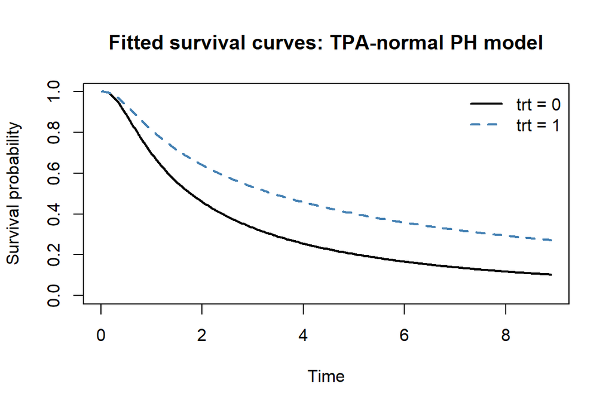

Fitted TPA-normal PH survival curves by treatment group

```r
eta_hat   <- exp(est[1]); phi_hat <- exp(est[2]); alpha_hat <- expit(est[3])
beta_hat  <- est[4]

tt <- seq(0.01, quantile(y, 0.95), length.out = 200)

# PH model: S(t | x) = S0(t)^exp(x * beta_hat)
S0 <- ptpa(tt, eta_hat, phi_hat, alpha_hat, F0_N, glog, lower.tail = FALSE)
S_trt0 <- S0^exp(0 * beta_hat)  # trt = 0
S_trt1 <- S0^exp(1 * beta_hat)  # trt = 1

plot(tt, S_trt0, type = "l", lwd = 2, ylim = c(0, 1),
     xlab = "Time", ylab = "Survival probability",
     main = "Fitted survival curves: TPA-normal PH model")
lines(tt, S_trt1, lwd = 2, lty = 2, col = "steelblue")
legend("topright", legend = c("trt = 0", "trt = 1"),
       lwd = 2, lty = c(1, 2), col = c("black", "steelblue"), bty = "n")
```

The fitted `beta_trt` should recover a value in the neighbourhood of the true -0.7 used to simulate the data, subject to sampling variability at `n = 300`; the printed 95% confidence interval for `beta_trt` should typically cover -0.7.

# 8 Function reference table

One-line summary of every function in this file

| Function | Purpose |
| --- | --- |
| f0_N/F0_N/QF_N | Normal reference density/CDF/quantile |
| f0_La/F0_La/QF_La | Laplace reference density/CDF/quantile |
| f0_Lo/F0_Lo/QF_Lo | Logistic reference density/CDF/quantile |
| glog/glog.inv, glogit/glogit.inv | Link functions for the time scale |
| dtpa | TPA family density |
| ptpa | TPA family CDF / survival function |
| htpa | TPA family hazard function |
| Htpa | TPA family cumulative hazard function |
| qtpa | TPA family quantile function |
| rtpa | Random draws from the TPA family |
| parHH_mle | Parametric MLE, Hybrid Hazard model |
| parGH_mle | Parametric MLE, General Hazards model |
| parAFT_mle | Parametric MLE, Accelerated Failure Time model |
| parPH_mle | Parametric MLE, Proportional Hazards model |
| parAH_mle | Parametric MLE, Accelerated Hazards model |
| ker | Kernel weight functions |
| nonparHH_mle | Local-likelihood MLE, HH model (hazard-scale smooth term) |
| nonparPH_mle | Local-likelihood MLE, PH model (hazard-scale smooth term) |
| nonparAFT_mle | Local-likelihood MLE, AFT model (time-scale smooth term) |
| nonparAH_mle | Local-likelihood MLE, AH model (time-scale smooth term) |
| surv_ase | Average squared error between two survival curves |
| predict_fun | Predicted survival/hazard/cum.hazard/quantile (see Sec. 9 note) |
| predict_plot | Simple plot of predicted quantity vs. time |
| trap_fun / trap_phihat | Trapezoidal-rule numerical integration of an estimated derivative |
| Conf.Int.FD | Finite-difference Wald confidence intervals |

# 9 Notes on the original code

1. **`predict_fun()` reads baseline parameters from a variable called `par`, not from its own `theta` argument.** In the original script the function signature includes a `theta` parameter that is documented but never used inside the function body; instead, every branch references an object literally called `par`. This works only if a suitably named vector `par` (natural-scale `c(eta, phi, alpha)`) happens to exist in the calling environment (for example, left over from a prior `optim()` call that used `par` as its variable name). In the worked example above we avoided `predict_fun()` for this reason and instead called `ptpa()`/`htpa()`/`Htpa()` directly with the fitted parameters. If you want to use `predict_fun()` as-is, define a variable named exactly `par <- c(eta_hat, phi_hat, alpha_hat)` before calling it.
2. **The `dist = "EW"` branches of `predict_fun()` call functions that are not defined or imported anywhere in this file** (`pexpweibull`, `hexpweibull`, `chexpweibull`, `qexpweibull` — these come from an Exponentiated-Weibull package that the original script never loads). These branches will fail with an “object not found” error unless you load a package that provides those four functions yourself.
3. **`nonparHH_mle()` and `nonparPH_mle()` implement `dist = "tpalnorm"` and `"tpallogis"` (and, for `nonparPH_mle()`, `"tpalLap"`)**, but do not implement a TPA log-Laplace branch for `nonparHH_mle()`. Calling `nonparHH_mle(..., dist = "tpalLap")` will error because `nlog.lik` is never assigned. This mirrors the original script exactly.
4. **`trap_phihat()` calls `is.sorted()`**, which is not a base-R function (base R provides `is.unsorted()`, whose negation is what’s presumably intended). This function will error immediately if called, in both the original script and this rewrite. Prefer `trap_fun()` (which uses `pracma::trapz()` and handles unsorted input automatically) unless you first fix this line yourself.
5. **All optimisers use `method = "Nelder-Mead"` by default**, a derivative-free method that is robust to a poorly chosen starting point but can be slow to converge for larger parameter vectors; for production use, consider trying `method = "nlminb"` or `method = "BFGS"` as well and comparing results, especially once you add more than a handful of covariates.

# 10 Original repository

- Source: https://github.com/Ewnetu-github/tpaHH
- Original single file: `Topic3_sourcecode.R`
- Original README: *“This is a source code for a hybrid hazard-based models using two-piece distributions. We proposed parametric, semi-parametric and non-parametric regression functions for the time-scale and relative hazard-scale change. Three parametric baseline distributions with a log-link function are included in the code: TPA normal, TPA logistic and TPA Laplace distributions.”*

This document (`tpaHH_two_piece_hazard_models.Rmd`) can be re-knitted at any time with:

```r
rmarkdown::render("tpaHH_two_piece_hazard_models.Rmd", output_format = "pdf_document")
rmarkdown::render("tpaHH_two_piece_hazard_models.Rmd", output_format = "word_document")
```